# MATH327 Project 2

Noah B Johnson

12/10/2017

# Analysis of Income Bracket Data with Logistic Regression

## Noah B Johnson, Data Science, Luther College

## Math 327, Dr. Philip Iverson

*Library Import Statements*

# Setup and Cleaning

```r
# Import the test and training datasets
nameslist = c("age","workclass","X1","education","education-num","marital-status","occupation","relationship","race","sex","capital-gain","capital-loss","hours-per-week","native-country","over50k")
training <- read_csv("data/training.csv",
    col_names = FALSE, skip = 1)
test <- read_csv("data/test.csv",
    col_names = FALSE, skip = 1)
# Set the names of the variables to those from the readme
names(training) = nameslist
names(test) = nameslist
# Remove the name list
remove(nameslist)

# Remove columns that will not be used
training$X1 = NULL
test$X1 = NULL
test$`capital-gain` = NULL
test$`capital-loss` = NULL
training$`capital-gain` = NULL
training$`capital-loss` = NULL
```

```r
# Replace the ? placeholder with NA
is.na(training) <- training == "?"
is.na(test) <- test == "?"
# Remove all records with NAs
training <- training[complete.cases(training),]
test <- test[complete.cases(test),]
# Fix typo in test response
trainpositive <- training$over50k == ">50K"
training$over50k[trainpositive] <- 1
training$over50k[!trainpositive] <- 0
testpositive <- test$over50k == ">50K."
test$over50k[testpositive] <- 1
test$over50k[!testpositive] <- 0
```

The dataset has been imported and the missing data points have all been standardized.

```r
# Create new dataframes with factored variables
f.training <- data.frame(training$age,factor(training$workclass),factor(training$education),training$`education-num`,factor(training$`marital-status`),factor(training$occupation),factor(training$relationship),factor(training$race),factor(training$sex),training$`hours-per-week`,factor(training$`native-country`),factor(training$over50k))
names(f.training) <- names(training)
f.test <- data.frame(test$age,factor(test$workclass),factor(test$education),test$`education-num`,factor(test$`marital-status`),factor(test$occupation),factor(test$relationship),factor(test$race),factor(test$sex),test$`hours-per-week`,factor(test$`native-country`),factor(test$over50k))
names(f.test) <- names(test)

# Copy factored dataframes to original data names
test <- f.test
training <- f.training

# Remove f. data frames
remove(f.test)
remove(f.training)
```

Categorical variables have been defines as “factors” for R processing.

# Introduction

The purpose of this analysis is to build a model that can accurately determine if someone’s income is over $50,000 or under/equal. The data used in this analysis was downloaded from the website data.world as a complete package including a training set and test set. (original attribution is at the end of this document) The data was originally obtained from the US census bureau and includes information about employment, education, and demographics. The variables are defined below.

**workclass:** Class of employer (private, self-employed, state gov., federal gov.) **education:** Highest level of education completed **marital-status:** Married, never married, separated, divorced **occupation:** The general industry of occupation (Sales, craftsman, manager/executive…) **relationship:** Family role **race:** Self-identified race **sex:** Self-identified sex **hours-per-week:** Number of hours worked on the average week **over50k:** **(response)** 1 = income > 50,000/yr, 0 = <= 50,000/yr

# Preliminary Analysis

## Variable Histograms

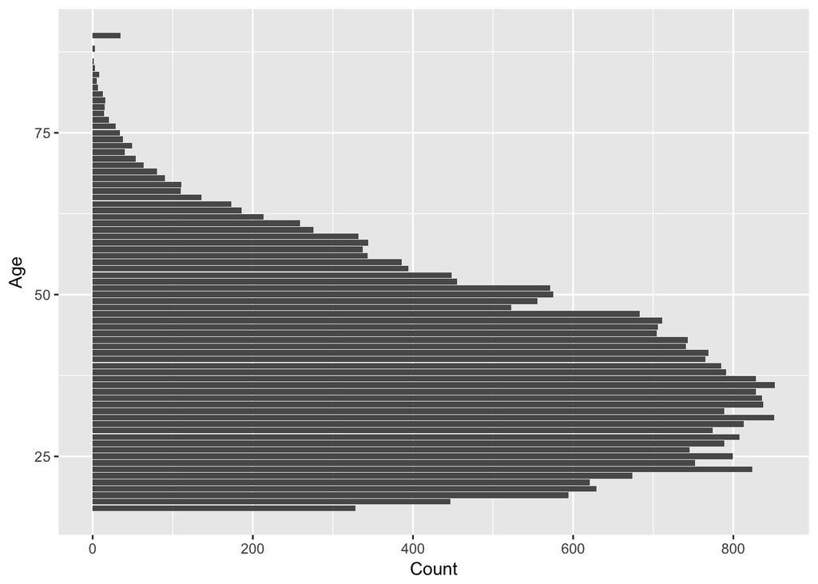

```r
ggplot(data = training,aes(x=training$age)) +
 xlab("Age") +
  ylab("Count") +
 coord_flip() +
  geom_bar()
```

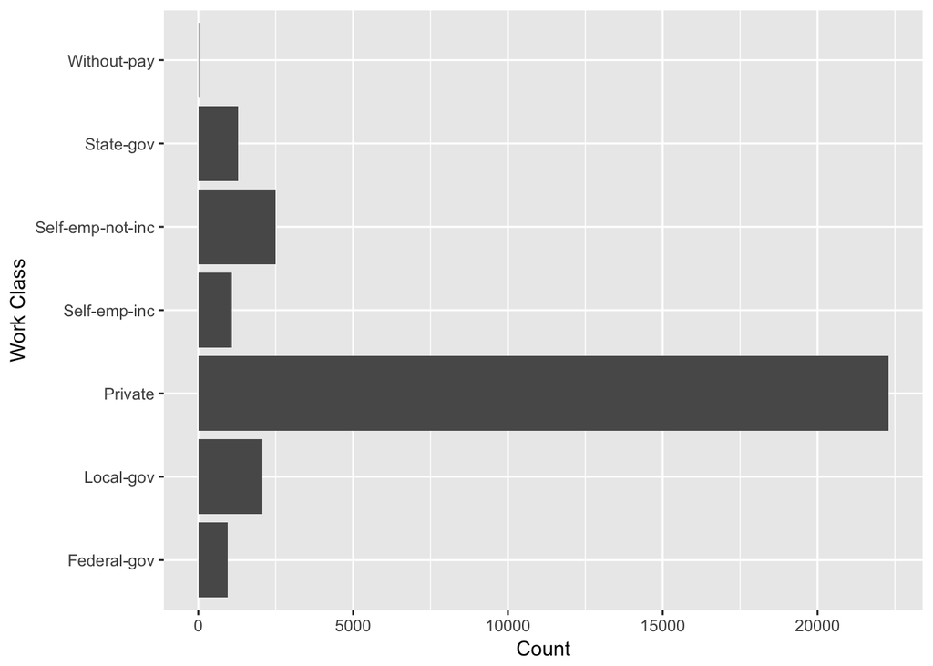

```r
ggplot(data = training,aes(x=training$workclass)) +
 xlab("Work Class") +
  ylab("Count") +
 coord_flip() +
  geom_bar()
```

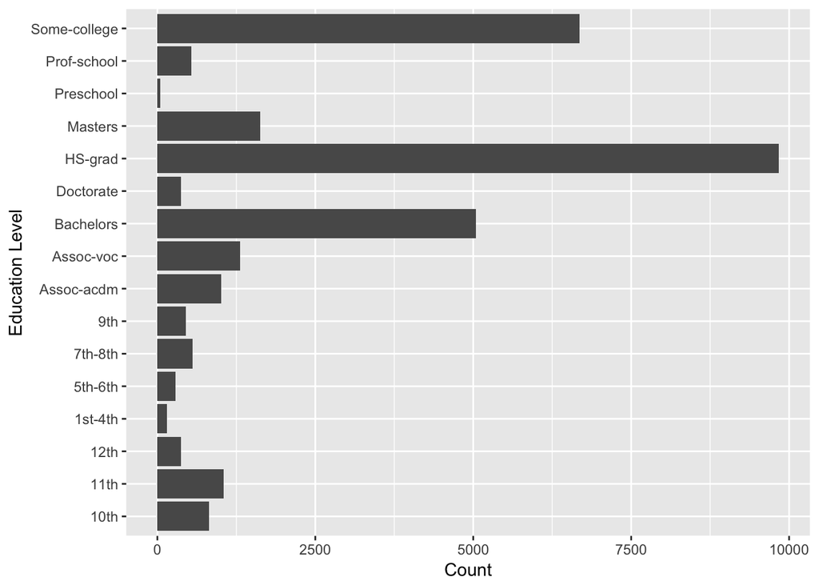

```r
ggplot(data = training,aes(x=training$education)) +
 xlab("Education Level") +
  ylab("Count") +
 coord_flip() +
  geom_bar()
```

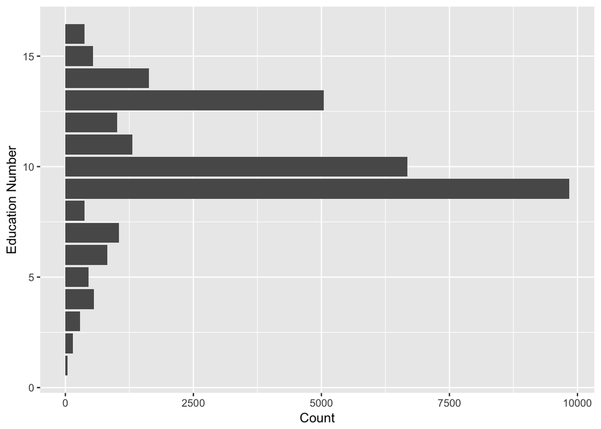

```r
ggplot(data = training,aes(x=training$`education-num`)) +
 xlab("Education Number") +
  ylab("Count") +
 coord_flip() +
  geom_bar()
```

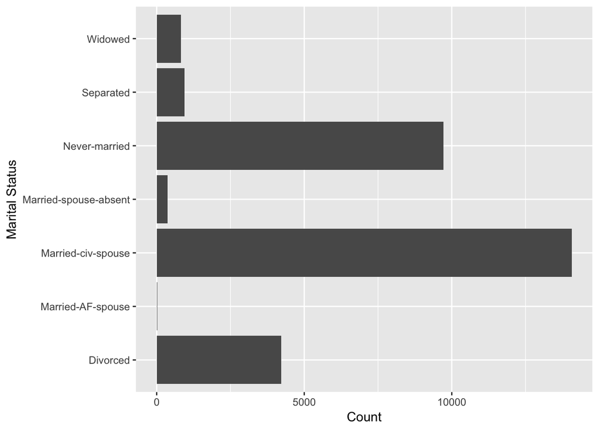

```r
ggplot(data = training,aes(x=training$`marital-status`)) +
 xlab("Marital Status") +
  ylab("Count") +
 coord_flip() +
  geom_bar()
```

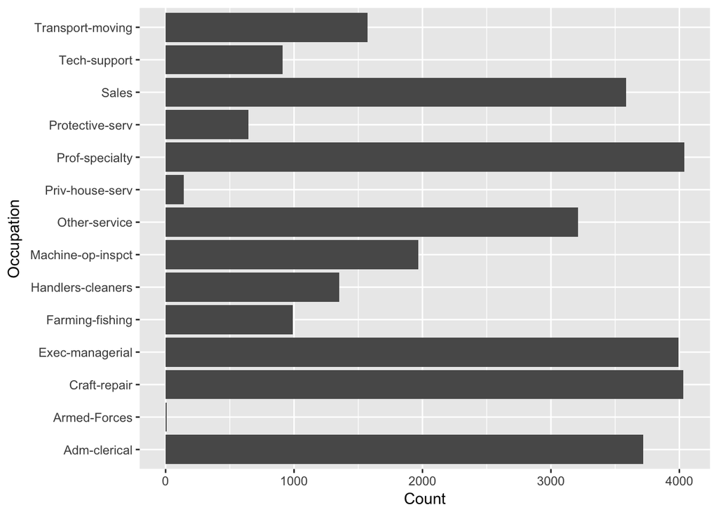

```r
ggplot(data = training,aes(x=training$occupation)) +
 xlab("Occupation") +
  ylab("Count") +
 coord_flip() +
  geom_bar()
```

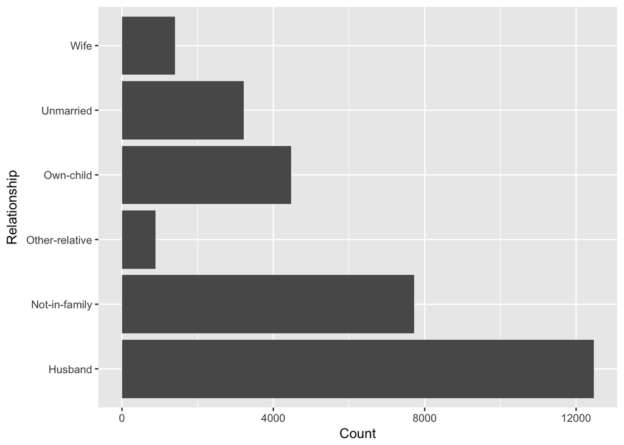

```r
ggplot(data = training,aes(x=training$relationship)) +
 xlab("Relationship") +
  ylab("Count") +
 coord_flip() +
  geom_bar()
```

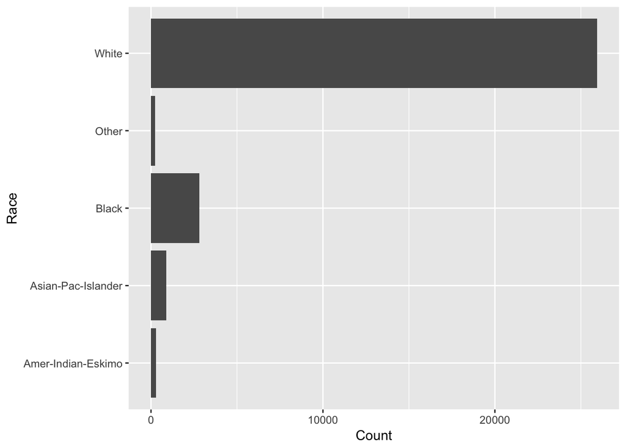

```r
ggplot(data = training,aes(x=training$race)) +
 xlab("Race") +
  ylab("Count") +
 coord_flip() +
  geom_bar()
```

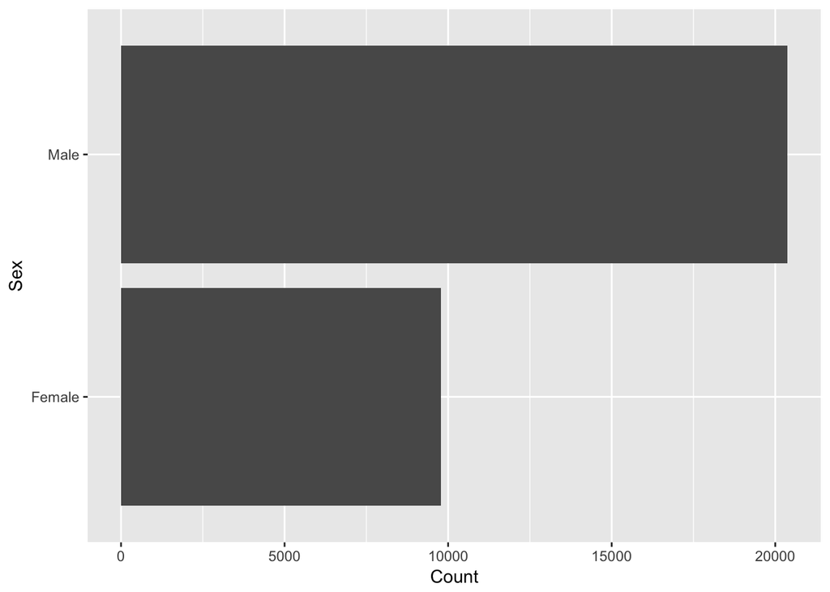

```r
ggplot(data = training,aes(x=training$sex)) +
 xlab("Sex") +
  ylab("Count") +
 coord_flip() +
  geom_bar()
```

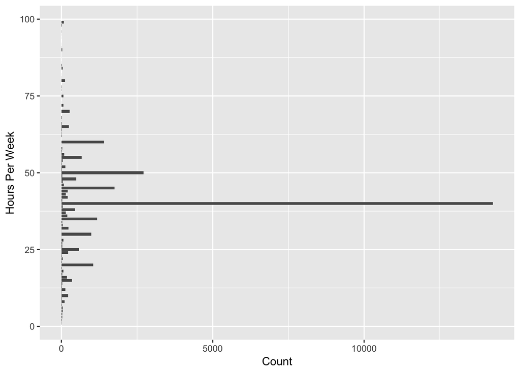

```r
ggplot(data = training,aes(x=training$`hours-per-week`)) +
 xlab("Hours Per Week") +
  ylab("Count") +
 coord_flip() +
  geom_bar()
```

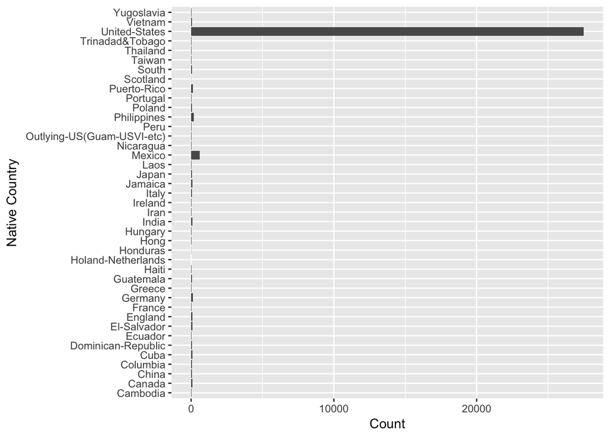

```r
ggplot(data = training,aes(x=training$`native-country`)) +
 xlab("Native Country") +
  ylab("Count") +
 coord_flip() +
  geom_bar()
```

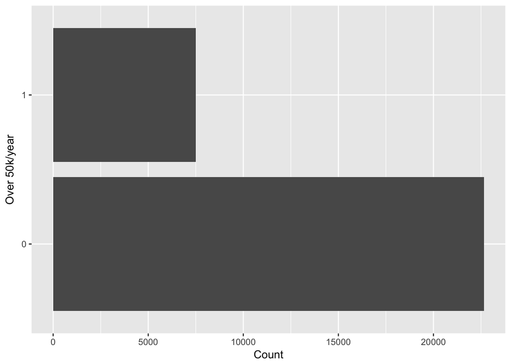

```r
ggplot(data = training,aes(x=training$over50k)) +
 xlab("Over 50k/year") +
  ylab("Count") +
 coord_flip() +
  geom_bar()
```

## Variable Summaries

```r
summary(training)
```

```
##       age                   workclass            education
##  Min.   :17.00   Federal-gov     :  943   HS-grad     :9840
##  1st Qu.:28.00   Local-gov       : 2067   Some-college:6678
##  Median :37.00   Private         :22286   Bachelors   :5043
##  Mean   :38.44   Self-emp-inc    : 1074   Masters     :1627
##  3rd Qu.:47.00   Self-emp-not-inc: 2499   Assoc-voc   :1307
##  Max.   :90.00   State-gov       : 1278   11th        :1048
##                  Without-pay     :   14   (Other)     :4618
##  education-num                 marital-status            occupation
##  Min.   : 1.00   Divorced             : 4214   Prof-specialty :4038
##  1st Qu.: 9.00   Married-AF-spouse    :   21   Craft-repair   :4030
##  Median :10.00   Married-civ-spouse   :14065   Exec-managerial:3992
##  Mean   :10.12   Married-spouse-absent:  370   Adm-clerical   :3720
##  3rd Qu.:13.00   Never-married        : 9725   Sales          :3584
##  Max.   :16.00   Separated            :  939   Other-service  :3212
##                  Widowed              :  827   (Other)        :7585
##          relationship                   race           sex
##  Husband       :12463   Amer-Indian-Eskimo:  286   Female: 9782
##  Not-in-family : 7725   Asian-Pac-Islander:  895   Male  :20379
##  Other-relative:  889   Black             : 2817
##  Own-child     : 4466   Other             :  231
##  Unmarried     : 3212   White             :25932
##  Wife          : 1406
##
##  hours-per-week        native-country  over50k
##  Min.   : 1.00   United-States:27503   0:22653
##  1st Qu.:40.00   Mexico       :  610   1: 7508
##  Median :40.00   Philippines  :  188
##  Mean   :40.93   Germany      :  128
##  3rd Qu.:45.00   Puerto-Rico  :  109
##  Max.   :99.00   Canada       :  107
##                  (Other)      : 1516
```

# First Order Model

```r
fit1 <- glm(over50k ~.,family=binomial(link='logit'),data=training)
summary(fit1)
```

```
##
## Call:
## glm(formula = over50k ~ ., family = binomial(link = "logit"),
##     data = training)
##
## Deviance Residuals:
##     Min       1Q   Median       3Q      Max
## -2.6858  -0.5705  -0.2171  -0.0005   3.6749
##
## Coefficients: (1 not defined because of singularities)
##                                              Estimate Std. Error z value
## (Intercept)                                 -6.016888   0.733590  -8.202
## age                                          0.028464   0.001624  17.525
## workclassLocal-gov                          -0.656320   0.107919  -6.082
## workclassPrivate                            -0.445512   0.089434  -4.981
## workclassSelf-emp-inc                       -0.213217   0.117397  -1.816
## workclassSelf-emp-not-inc                   -0.909069   0.104633  -8.688
## workclassState-gov                          -0.843126   0.120163  -7.017
## workclassWithout-pay                       -13.397406 195.110394  -0.069
## education11th                                0.144269   0.205751   0.701
## education12th                                0.489698   0.261672   1.871
## education1st-4th                            -0.427463   0.471036  -0.907
## education5th-6th                            -0.359834   0.350328  -1.027
## education7th-8th                            -0.560838   0.235288  -2.384
## education9th                                -0.309372   0.262644  -1.178
## educationAssoc-acdm                          1.322308   0.171560   7.708
## educationAssoc-voc                           1.339030   0.164649   8.133
## educationBachelors                           1.984515   0.153440  12.933
## educationDoctorate                           3.089043   0.211261  14.622
## educationHS-grad                             0.814238   0.149289   5.454
## educationMasters                             2.400260   0.163738  14.659
## educationPreschool                         -11.093025 109.105061  -0.102
## educationProf-school                         3.084185   0.195151  15.804
## educationSome-college                        1.148735   0.151467   7.584
## `education-num`                                    NA         NA      NA
## `marital-status`Married-AF-spouse            2.512458   0.566562   4.435
## `marital-status`Married-civ-spouse           1.996330   0.266502   7.491
## `marital-status`Married-spouse-absent       -0.037378   0.221597  -0.169
## `marital-status`Never-married               -0.453964   0.081665  -5.559
## `marital-status`Separated                   -0.065162   0.151384  -0.430
```

[output cut: 155 more lines]

```
## `native-country`Thailand                   0.031999 *
## `native-country`Trinadad&Tobago            0.087954 .
## `native-country`United-States              0.094012 .
## `native-country`Vietnam                    0.004993 **
## `native-country`Yugoslavia                 0.493344
## ---
## Signif. codes:  0 '***' 0.001 '**' 0.01 '*' 0.05 '.' 0.1 ' ' 1
##
## (Dispersion parameter for binomial family taken to be 1)
##
##     Null deviance: 33850  on 30160  degrees of freedom
## Residual deviance: 21433  on 30068  degrees of freedom
## AIC: 21619
##
## Number of Fisher Scoring iterations: 13
```

```r
# Nationality is not very significant and is a pain due to categories
test$`native-country` <- NULL
training$`native-country` <- NULL

# education-num is throwing an error and is a reapeat of education
test$`education-num` <- NULL
training$`education-num` <- NULL
```

The first order model improves upon the accuracy of the null model by over 30%, but there are some duplicate predictors, and many variables appear to be insignificant.

Nationality and education-num are removed as variables. education-num is a duplicate variable, and native-country is poorly distributed and difficult to draw conclusions from.

```r
fit2 <- glm(over50k ~.,family=binomial(link='logit'),data=training)
summary(fit2)
```

```
##
## Call:
## glm(formula = over50k ~ ., family = binomial(link = "logit"),
##     data = training)
##
## Deviance Residuals:
##     Min       1Q   Median       3Q      Max
## -2.7437  -0.5730  -0.2192  -0.0006   3.6405
##
## Coefficients:
##                                         Estimate Std. Error z value
## (Intercept)                            -7.034996   0.404859 -17.376
## age                                     0.028960   0.001615  17.927
## workclassLocal-gov                     -0.660434   0.107774  -6.128
## workclassPrivate                       -0.455772   0.089338  -5.102
## workclassSelf-emp-inc                  -0.231784   0.117181  -1.978
## workclassSelf-emp-not-inc              -0.928889   0.104437  -8.894
## workclassState-gov                     -0.857645   0.120067  -7.143
## workclassWithout-pay                  -13.368864 195.206047  -0.068
## education11th                           0.137461   0.205407   0.669
## education12th                           0.460301   0.260051   1.770
## education1st-4th                       -0.635780   0.455069  -1.397
## education5th-6th                       -0.519914   0.338798  -1.535
## education7th-8th                       -0.598798   0.234541  -2.553
## education9th                           -0.370078   0.261742  -1.414
## educationAssoc-acdm                     1.333289   0.171182   7.789
## educationAssoc-voc                      1.344624   0.164353   8.181
## educationBachelors                      1.991870   0.153137  13.007
## educationDoctorate                      3.058580   0.210505  14.530
## educationHS-grad                        0.819688   0.149064   5.499
## educationMasters                        2.384468   0.163322  14.600
## educationPreschool                    -11.364673 110.388547  -0.103
## educationProf-school                    3.071556   0.194675  15.778
## educationSome-college                   1.156325   0.151217   7.647
## `marital-status`Married-AF-spouse       2.504651   0.566067   4.425
## `marital-status`Married-civ-spouse      1.970402   0.264778   7.442
## `marital-status`Married-spouse-absent  -0.075342   0.219638  -0.343
## `marital-status`Never-married          -0.450995   0.081404  -5.540
## `marital-status`Separated              -0.069537   0.151268  -0.460
## `marital-status`Widowed                 0.151450   0.143852   1.053
```

[output cut: 73 more lines]

```
## raceBlack                             0.053699 .
## raceOther                             0.530068
## raceWhite                             0.014777 *
## sexMale                                < 2e-16 ***
## `hours-per-week`                       < 2e-16 ***
## ---
## Signif. codes:  0 '***' 0.001 '**' 0.01 '*' 0.05 '.' 0.1 ' ' 1
##
## (Dispersion parameter for binomial family taken to be 1)
##
##     Null deviance: 33850  on 30160  degrees of freedom
## Residual deviance: 21519  on 30108  degrees of freedom
## AIC: 21625
##
## Number of Fisher Scoring iterations: 13
```

The model without native-country and education-num is much cleaner and easier to analyze.

# Model Selection

## Steps

```r
# empty regression model
model.null = glm(over50k ~ 1,
                 data=training,
                 family = binomial(link="logit")
                 )

# full regression model
model.full = glm(over50k ~ .,
                 data=training,
                 family = binomial(link="logit")
                 )

step(model.null,
     scope = list(upper=model.full),
             direction="both",
             test="Chisq",
             data=Data)
```

```
## Start:  AIC=33852.14
## over50k ~ 1
##
##                    Df Deviance   AIC    LRT  Pr(>Chi)
## + relationship      5    26902 26914 6948.1 < 2.2e-16 ***
## + `marital-status`  6    27266 27280 6583.9 < 2.2e-16 ***
## + education        15    29944 29976 3905.6 < 2.2e-16 ***
## + occupation       13    29954 29982 3896.5 < 2.2e-16 ***
## + age               1    32112 32116 1738.5 < 2.2e-16 ***
## + `hours-per-week`  1    32232 32236 1618.5 < 2.2e-16 ***
## + sex               1    32286 32290 1564.3 < 2.2e-16 ***
## + workclass         6    33135 33149  715.3 < 2.2e-16 ***
## + race              4    33503 33513  346.8 < 2.2e-16 ***
## <none>                   33850 33852
## ---
## Signif. codes:  0 '***' 0.001 '**' 0.01 '*' 0.05 '.' 0.1 ' ' 1
##
## Step:  AIC=26914
## over50k ~ relationship
##
##                    Df Deviance   AIC    LRT  Pr(>Chi)
## + education        15    23485 23527 3417.5 < 2.2e-16 ***
## + occupation       13    23961 23999 2940.7 < 2.2e-16 ***
## + `hours-per-week`  1    26296 26310  606.1 < 2.2e-16 ***
## + workclass         6    26530 26554  372.2 < 2.2e-16 ***
## + age               1    26581 26595  321.3 < 2.2e-16 ***
## + `marital-status`  6    26761 26785  140.7 < 2.2e-16 ***
## + sex               1    26784 26798  118.3 < 2.2e-16 ***
## + race              4    26791 26811  111.1 < 2.2e-16 ***
## <none>                   26902 26914
## - relationship      5    33850 33852 6948.1 < 2.2e-16 ***
## ---
## Signif. codes:  0 '***' 0.001 '**' 0.01 '*' 0.05 '.' 0.1 ' ' 1
##
## Step:  AIC=23526.54
## over50k ~ relationship + education
##
##                    Df Deviance   AIC    LRT  Pr(>Chi)
## + occupation       13    22634 22702  850.2 < 2.2e-16 ***
## + `hours-per-week`  1    23117 23161  367.6 < 2.2e-16 ***
```

[output cut: 119 more lines]

```
##     age + sex + workclass + `marital-status` + race
##
##                    Df Deviance   AIC     LRT  Pr(>Chi)
## <none>                   21519 21625
## - race              4    21536 21634   17.33  0.001665 **
## - `marital-status`  6    21623 21717  104.55 < 2.2e-16 ***
## - workclass         6    21659 21753  139.80 < 2.2e-16 ***
## - sex               1    21661 21765  141.87 < 2.2e-16 ***
## - relationship      5    21838 21934  319.41 < 2.2e-16 ***
## - age               1    21845 21949  325.92 < 2.2e-16 ***
## - `hours-per-week`  1    21872 21976  353.33 < 2.2e-16 ***
## - occupation       13    22202 22282  683.54 < 2.2e-16 ***
## - education        15    22766 22842 1246.71 < 2.2e-16 ***
## ---
## Signif. codes:  0 '***' 0.001 '**' 0.01 '*' 0.05 '.' 0.1 ' ' 1
```

```
##
## Call:  glm(formula = over50k ~ relationship + education + occupation +
##     `hours-per-week` + age + sex + workclass + `marital-status` +
##     race, family = binomial(link = "logit"), data = training)
##
## Coefficients:
##                           (Intercept)
##                              -7.03500
##             relationshipNot-in-family
##                               0.44468
##            relationshipOther-relative
##                              -0.44720
##                 relationshipOwn-child
##                              -0.76558
##                 relationshipUnmarried
##                               0.24581
##                      relationshipWife
##                               1.34737
##                         education11th
##                               0.13746
##                         education12th
##                               0.46030
##                      education1st-4th
##                              -0.63578
##                      education5th-6th
##                              -0.51991
##                      education7th-8th
##                              -0.59880
##                          education9th
##                              -0.37008
##                   educationAssoc-acdm
##                               1.33329
##                    educationAssoc-voc
##                               1.34462
##                    educationBachelors
##                               1.99187
##                    educationDoctorate
##                               3.05858
##                      educationHS-grad
##                               0.81969
```

[output cut: 61 more lines]

```
##                              -0.06954
##               `marital-status`Widowed
##                               0.15145
##                raceAsian-Pac-Islander
##                               0.37478
##                             raceBlack
##                               0.43290
##                             raceOther
##                              -0.21893
##                             raceWhite
##                               0.52239
##
## Degrees of Freedom: 30160 Total (i.e. Null);  30108 Residual
## Null Deviance:       33850
## Residual Deviance: 21520     AIC: 21620
```

```r
# Best model has all predictors in it, same as fit2
fit <- fit2
```

Bidirectional stepping using the AIC criterion has determined that the best model is model.full, which contains all of the variables.

## Final Model

```r
summary(fit)
```

```
##
## Call:
## glm(formula = over50k ~ ., family = binomial(link = "logit"),
##     data = training)
##
## Deviance Residuals:
##     Min       1Q   Median       3Q      Max
## -2.7437  -0.5730  -0.2192  -0.0006   3.6405
##
## Coefficients:
##                                         Estimate Std. Error z value
## (Intercept)                            -7.034996   0.404859 -17.376
## age                                     0.028960   0.001615  17.927
## workclassLocal-gov                     -0.660434   0.107774  -6.128
## workclassPrivate                       -0.455772   0.089338  -5.102
## workclassSelf-emp-inc                  -0.231784   0.117181  -1.978
## workclassSelf-emp-not-inc              -0.928889   0.104437  -8.894
## workclassState-gov                     -0.857645   0.120067  -7.143
## workclassWithout-pay                  -13.368864 195.206047  -0.068
## education11th                           0.137461   0.205407   0.669
## education12th                           0.460301   0.260051   1.770
## education1st-4th                       -0.635780   0.455069  -1.397
## education5th-6th                       -0.519914   0.338798  -1.535
## education7th-8th                       -0.598798   0.234541  -2.553
## education9th                           -0.370078   0.261742  -1.414
## educationAssoc-acdm                     1.333289   0.171182   7.789
## educationAssoc-voc                      1.344624   0.164353   8.181
## educationBachelors                      1.991870   0.153137  13.007
## educationDoctorate                      3.058580   0.210505  14.530
## educationHS-grad                        0.819688   0.149064   5.499
## educationMasters                        2.384468   0.163322  14.600
## educationPreschool                    -11.364673 110.388547  -0.103
## educationProf-school                    3.071556   0.194675  15.778
## educationSome-college                   1.156325   0.151217   7.647
## `marital-status`Married-AF-spouse       2.504651   0.566067   4.425
## `marital-status`Married-civ-spouse      1.970402   0.264778   7.442
## `marital-status`Married-spouse-absent  -0.075342   0.219638  -0.343
## `marital-status`Never-married          -0.450995   0.081404  -5.540
## `marital-status`Separated              -0.069537   0.151268  -0.460
## `marital-status`Widowed                 0.151450   0.143852   1.053
```

[output cut: 73 more lines]

```
## raceBlack                             0.053699 .
## raceOther                             0.530068
## raceWhite                             0.014777 *
## sexMale                                < 2e-16 ***
## `hours-per-week`                       < 2e-16 ***
## ---
## Signif. codes:  0 '***' 0.001 '**' 0.01 '*' 0.05 '.' 0.1 ' ' 1
##
## (Dispersion parameter for binomial family taken to be 1)
##
##     Null deviance: 33850  on 30160  degrees of freedom
## Residual deviance: 21519  on 30108  degrees of freedom
## AIC: 21625
##
## Number of Fisher Scoring iterations: 13
```

```r
anova(fit)
```

```
## Analysis of Deviance Table
##
## Model: binomial, link: logit
##
## Response: over50k
##
## Terms added sequentially (first to last)
##
##
##                  Df Deviance Resid. Df Resid. Dev
## NULL                             30160      33850
## age               1   1738.5     30159      32112
## workclass         6    426.2     30153      31685
## education        15   3570.5     30138      28115
## `marital-status`  6   5090.8     30132      23024
## occupation       13    765.5     30119      22259
## relationship      5    199.6     30114      22059
## race              4     21.3     30110      22038
## sex               1    165.8     30109      21872
## `hours-per-week`  1    353.3     30108      21519
```

# Model Diagnostics

## ANOVA

```r
Anova(fit, type="II", test="Wald")
```

```
## Analysis of Deviance Table (Type II tests)
##
## Response: over50k
##                  Df    Chisq Pr(>Chisq)
## age               1  321.391  < 2.2e-16 ***
## workclass         6  131.848  < 2.2e-16 ***
## education        15 1103.829  < 2.2e-16 ***
## `marital-status`  6  115.431  < 2.2e-16 ***
## occupation       13  626.900  < 2.2e-16 ***
## relationship      5  289.869  < 2.2e-16 ***
## race              4   16.066   0.002932 **
## sex               1  136.893  < 2.2e-16 ***
## `hours-per-week`  1  342.856  < 2.2e-16 ***
## ---
## Signif. codes:  0 '***' 0.001 '**' 0.01 '*' 0.05 '.' 0.1 ' ' 1
```

```r
anova(fit, test="Chisq")
```

```
## Analysis of Deviance Table
##
## Model: binomial, link: logit
##
## Response: over50k
##
## Terms added sequentially (first to last)
##
##
##                  Df Deviance Resid. Df Resid. Dev  Pr(>Chi)
## NULL                             30160      33850
## age               1   1738.5     30159      32112 < 2.2e-16 ***
## workclass         6    426.2     30153      31685 < 2.2e-16 ***
## education        15   3570.5     30138      28115 < 2.2e-16 ***
## `marital-status`  6   5090.8     30132      23024 < 2.2e-16 ***
## occupation       13    765.5     30119      22259 < 2.2e-16 ***
## relationship      5    199.6     30114      22059 < 2.2e-16 ***
## race              4     21.3     30110      22038 0.0002798 ***
## sex               1    165.8     30109      21872 < 2.2e-16 ***
## `hours-per-week`  1    353.3     30108      21519 < 2.2e-16 ***
## ---
## Signif. codes:  0 '***' 0.001 '**' 0.01 '*' 0.05 '.' 0.1 ' ' 1
```

The analysis of deviance table indicates that all of the variables are significant at the .01 level.

## Pseudo-R^2

```r
R2 <- pR2(fit)
rsquared <- R2[4]
names(rsquared) <- NULL
nagelkerke(fit)
```

```
## $Models
##
## Model: "glm, over50k ~ ., binomial(link = \"logit\"), training"
## Null:  "glm, over50k ~ 1, binomial(link = \"logit\"), training"
##
## $Pseudo.R.squared.for.model.vs.null
##                              Pseudo.R.squared
## McFadden                             0.364293
## Cox and Snell (ML)                   0.335587
## Nagelkerke (Cragg and Uhler)         0.497553
##
## $Likelihood.ratio.test
##  Df.diff LogLik.diff Chisq p.value
##      -52     -6165.7 12331       0
##
## $Number.of.observations
##
## Model: 30161
## Null:  30161
##
## $Messages
## [1] "Note: For models fit with REML, these statistics are based on refitting with ML"
##
## $Warnings
## [1] "None"
```

Pseudo-R2 values derived from the model indicate a decent fit.

## P-value from chi-squared

```r
anova(fit,
      model.null,
      test="Chisq")
```

```
## Analysis of Deviance Table
##
## Model 1: over50k ~ age + workclass + education + `marital-status` + occupation +
##     relationship + race + sex + `hours-per-week`
## Model 2: over50k ~ 1
##   Resid. Df Resid. Dev  Df Deviance  Pr(>Chi)
## 1     30108      21519
## 2     30160      33850 -52   -12331 < 2.2e-16 ***
## ---
## Signif. codes:  0 '***' 0.001 '**' 0.01 '*' 0.05 '.' 0.1 ' ' 1
```

```r
lrtest(fit)
```

```
## Likelihood ratio test
##
## Model 1: over50k ~ age + workclass + education + `marital-status` + occupation +
##     relationship + race + sex + `hours-per-week`
## Model 2: over50k ~ 1
##   #Df LogLik  Df Chisq Pr(>Chisq)
## 1  53 -10759
## 2   1 -16925 -52 12331  < 2.2e-16 ***
## ---
## Signif. codes:  0 '***' 0.001 '**' 0.01 '*' 0.05 '.' 0.1 ' ' 1
```

## Residuals plots

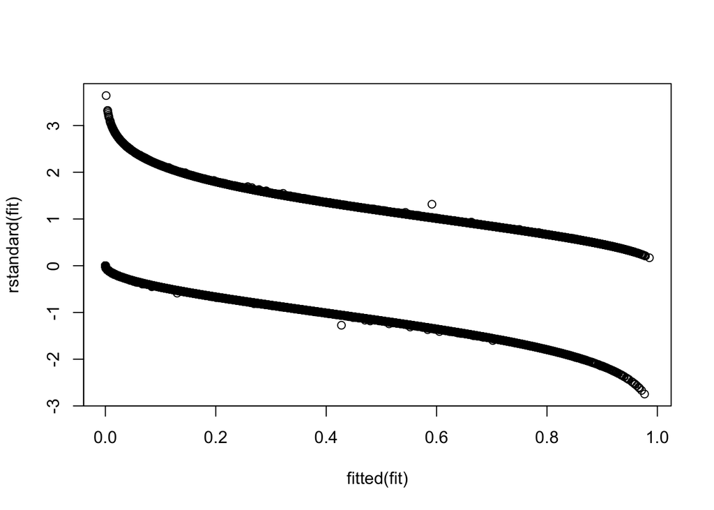

```r
plot(fitted(fit),
     rstandard(fit))
```

Plotting the standard residuals against the fitted value indicates some bias, but there are no obvious outliers.

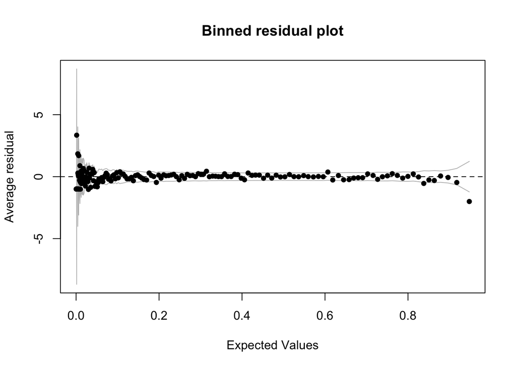

```r
binnedplot(fit$fitted.values,fit$residuals)
```

The binned residual plot is a better indicator in this case. To indicate good fit, about 95% of the values should fit within the gray lines on the plot, and this is the case.

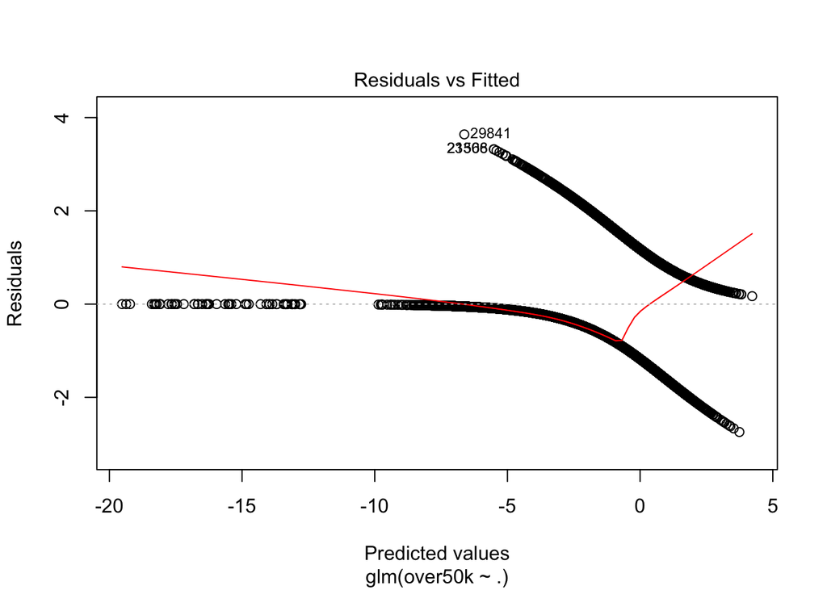

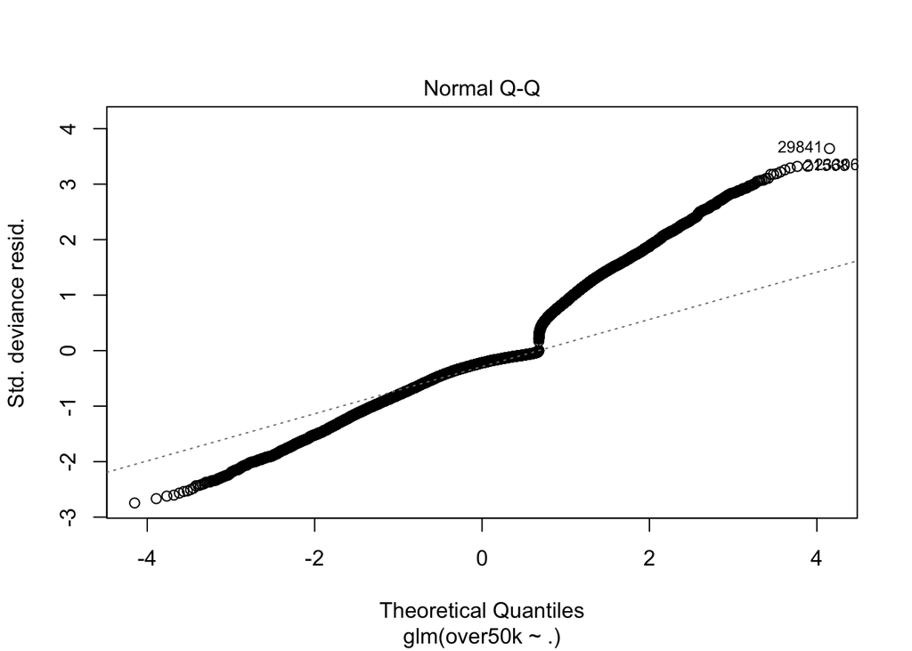

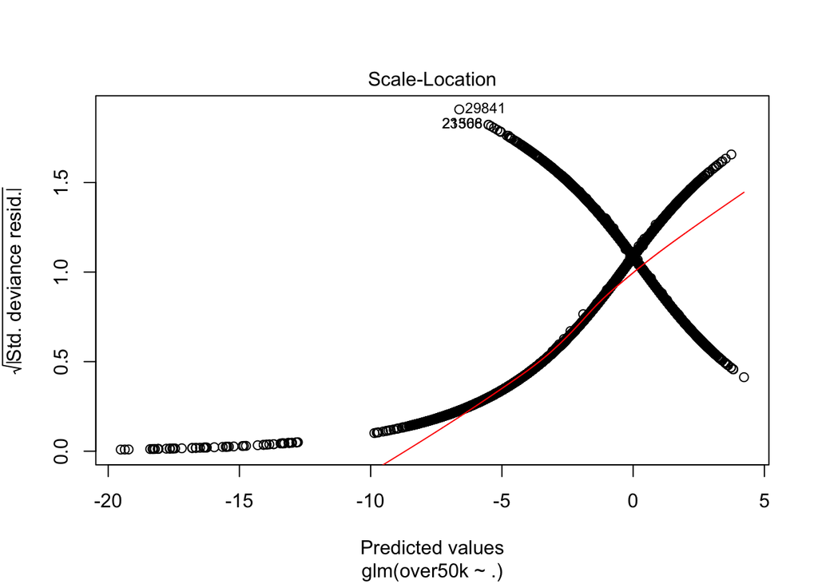

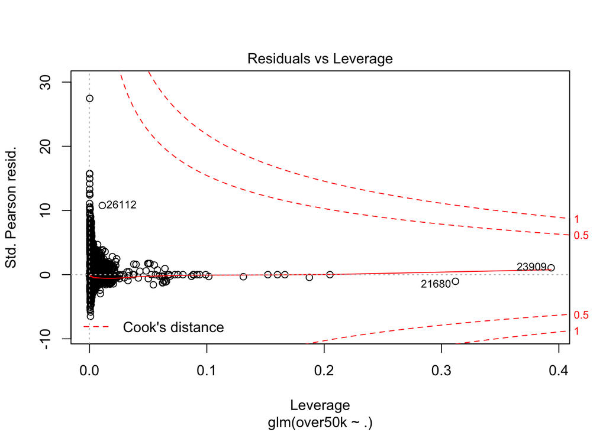

```r
plot(fit)
```

The model plots above do not make any highly-influential observations apparent.

# Conclusion

```r
fitted.results <- predict(fit,newdata=training)
```

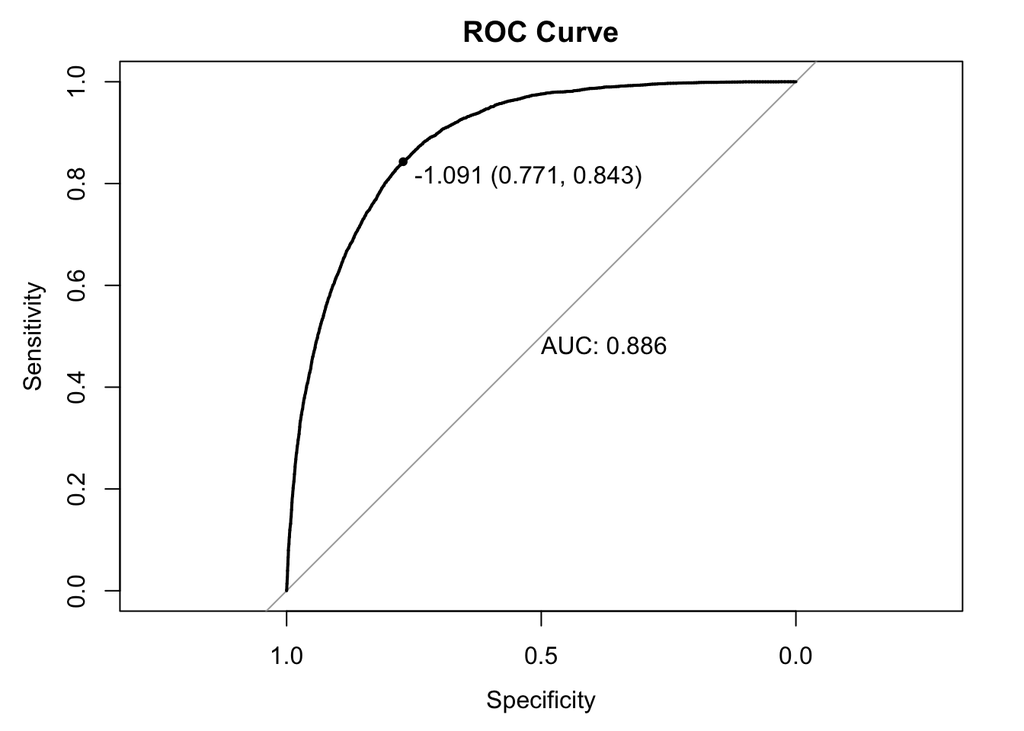

```r
rocmodel <- roc(training$over50k,fitted.results)
pROC::plot.roc(rocmodel,print.thres = TRUE,print.auc = TRUE,main = "ROC Curve")
```

```r
test.results <- predict(fit,newdata=test)
fitted.results.binary <- ifelse(test.results > -1.091,1,0)
misClasificError <- mean(fitted.results.binary != test$over50k)
print(paste('Accuracy',1-misClasificError))
```

```
## [1] "Accuracy 0.786174380768975"
```

Observation of the ROC curve indicates a threshold of -1.091 for highest overall accuracy. Using this threshold on our test dataset results in determining, with 78.62% accuracy if an individual has above or below $50,000/yr in income. Finding over 75% accuracy with the test set indicates that the model can be applied to new observations without losing much integrity.

### Attribution

This data was extracted from the census bureau database found at  
http://www.census.gov/ftp/pub/DES/www/welcome.html  
Donor: Ronny Kohavi and Barry Becker,  
Data Mining and Visualization  
Silicon Graphics.  
e-mail: ronnyk@sgi.com for questions.  
Split into train-test using MLC++ GenCVFiles (2/3, 1/3 random).  
48842 instances, mix of continuous and discrete (train=32561, test=16281)  
45222 if instances with unknown values are removed (train=30162, test=15060)  
Duplicate or conflicting instances : 6  
Class probabilities for adult.all file  
Probability for the label ‘>50K’ : 23.93% / 24.78% (without unknowns)  
Probability for the label ‘<=50K’ : 76.07% / 75.22% (without unknowns)  
Extraction was done by Barry Becker from the 1994 Census database. A set of  
reasonably clean records was extracted using the following conditions:  
((AAGE>16) && (AGI>100) && (AFNLWGT>1)&& (HRSWK>0))  
Conversion of original data as follows:  
1. Discretized agrossincome into two ranges with threshold 50,000.  
2. Convert U.S. to US to avoid periods.  
3. Convert Unknown to “?”  
4. Run MLC++ GenCVFiles to generate data,test.  
Description of fnlwgt (final weight)  
The weights on the CPS files are controlled to independent estimates of the  
civilian noninstitutional population of the US. These are prepared monthly  
for us by Population Division here at the Census Bureau. We use 3 sets of  
controls.  
These are:  
1. A single cell estimate of the population 16+ for each state.  
2. Controls for Hispanic Origin by age and sex.  
3. Controls by Race, age and sex.  
We use all three sets of controls in our weighting program and “rake” through  
them 6 times so that by the end we come back to all the controls we used.  
The term estimate refers to population totals derived from CPS by creating  
“weighted tallies” of any specified socio-economic characteristics of the  
population.  
People with similar demographic characteristics should have  
similar weights. There is one important caveat to remember  
about this statement. That is that since the CPS sample is  
actually a collection of 51 state samples, each with its own  
probability of selection, the statement only applies within  
state.

> 50K, <=50K.

age: continuous. workclass: Private, Self-emp-not-inc, Self-emp-inc, Federal-gov, Local-gov, State-gov, Without-pay, Never-worked. fnlwgt: continuous. education: Bachelors, Some-college, 11th, HS-grad, Prof-school, Assoc-acdm, Assoc-voc, 9th, 7th-8th, 12th, Masters, 1st-4th, 10th, Doctorate, 5th-6th, Preschool. education-num: continuous. marital-status: Married-civ-spouse, Divorced, Never-married, Separated, Widowed, Married-spouse-absent, Married-AF-spouse. occupation: Tech-support, Craft-repair, Other-service, Sales, Exec-managerial, Prof-specialty, Handlers-cleaners, Machine-op-inspct, Adm-clerical, Farming-fishing, Transport-moving, Priv-house-serv, Protective-serv, Armed-Forces. relationship: Wife, Own-child, Husband, Not-in-family, Other-relative, Unmarried. race: White, Asian-Pac-Islander, Amer-Indian-Eskimo, Other, Black. sex: Female, Male. capital-gain: continuous. capital-loss: continuous. hours-per-week: continuous. native-country: United-States, Cambodia, England, Puerto-Rico, Canada, Germany, Outlying-US(Guam-USVI-etc), India, Japan, Greece, South, China, Cuba, Iran, Honduras, Philippines, Italy, Poland, Jamaica, Vietnam, Mexico, Portugal, Ireland, France, Dominican-Republic, Laos, Ecuador, Taiwan, Haiti, Columbia, Hungary, Guatemala, Nicaragua, Scotland, Thailand, Yugoslavia, El-Salvador, Trinadad&Tobago, Peru, Hong, Holand-Netherlands.